# Lab10_Johnbauer

John Bauer

2024-03-27

```r
library(tidyverse)
```

```r
library(plotly)
library(knitr)
library(DT)
```

# Exercise 1

## NEON Site: Toolik Field Station

[figure not shown]

Toolik Field Station (University of Alaska Fairbanks n.d.)

Located 400 miles north from Fairbanks, Alaska at the foot of the Brooks mountain range, biodiversity at Toolik Field Station is heavily influenced by its harsh winters where temperatures can reach -50⁰F. It is home to a variety of fauna including caribou, loons, voles, and polar bears. Located above the northern tree line, the vegetation in the tundra here mainly consists of birch, willow, sedges and grass. The site contains a large range of soil conditions, including layers of permafrost, created by glacial action (NEON 2023).

# Exercise 2

## Gammaproteobacteria

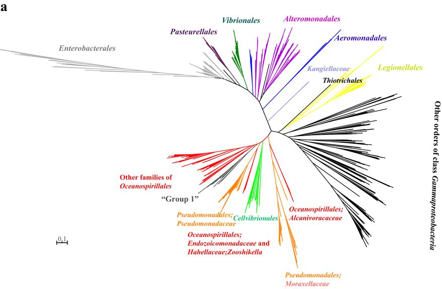

Uprooted maximum-likelyhood phylogentic tree of gammaproteobactria based on 120 concatenated single copy proteins sequences from 780 reference genomes (Liao et al. 2020). Figure adapted from Figure 2 of Liao et al.

The class Gammaproteobacteria, under the phylum Proteobacteria, is made up of around 381 genera that thrive in marine, terrestial, and eukaryotic host ecosystems (Liao et al. 2020). Historically, this class has be defined phylogenetically by 16s rRNA sequence homology (Williams and Kelly 2013). Some notable members of this class include *Escherichia coli*, *Vibrio fischeri*, and *Pseudomonas aeruginosa*. This class has great diversity of morphologies with rod, cocci, spirilla, and filaments all represented (Williams et al. 2010). Additionally, species in class display a variety of trophisms including chemoautotrophs and photoautotrophs (Gao, Mohan, and Gupta 2009).

# Exercise 3

```r
NEON_MAGs <- read_csv("~/Bio 676/Lab10/data/GOLD_Study_ID_Gs0161344_NEON_edArchaea.csv") %>%
  # remove columns that are not needed for data analysis
  select(-c(`GOLD Study ID`, `Bin Methods`, `Created By`, `Date Added`)) %>%
  # create a new column with the Assembly Type
  mutate("Assembly Type" = case_when(`Genome Name` == "NEON combined assembly" ~ `Genome Name`,
                            TRUE ~ "Individual")) %>%
  mutate_at("Assembly Type", str_replace, "NEON combined assembly", "Combined") %>%
  separate(`GTDB-Tk Taxonomy Lineage`, c("Domain", "Phylum", "Class", "Order", "Family", "Genus"), "; ", remove = FALSE) %>%
  # Get rid of the the common string "Soil microbial communities from "
  mutate_at("Genome Name", str_replace, "Terrestrial soil microbial communities from ", "") %>%
  # Use the first `-` to split the column in two
  separate(`Genome Name`, c("Site","Sample Name"), " - ") %>%
  # Get rid of the the common string "S-comp-1"
  mutate_at("Sample Name", str_replace, "-comp-1", "") %>%
  # separate the Sample Name into Site ID and plot info
  separate(`Sample Name`, c("Site ID","subplot.layer.date"), "_", remove = FALSE,) %>%
  # separate the plot info into 3 columns
  separate(`subplot.layer.date`, c("Subplot", "Layer", "Date"), "-")
NEON_MAGs_Toolik <- NEON_MAGs %>%
  filter(str_detect(`Site`, 'Toolik Field Station'))

NEON_MAGs_Toolik_GPROTEO <- NEON_MAGs_Toolik %>%
  filter(str_detect(`Class`, 'Gammaproteobacteria'))

NEON_MAGs_GPROTEO <- NEON_MAGs %>%
  filter(str_detect(`Class`, 'Gammaproteobacteria'))
```

## Toolik Field Station MAGs

```r
datatable(NEON_MAGs_Toolik)
```

|  | Bin ID | Site | Sample Name | Site ID | Subplot | Layer | Date | IMG Genome ID | Bin Quality | Bin Lineage | GTDB-Tk Taxonomy Lineage | Domain | Phylum | Class | Order | Family | Genus | Bin Completeness | Bin Contamination | Total Number of Bases | 5s rRNA | 16s rRNA | 23s rRNA | tRNA Genes | Gene Count | Scaffold Count | Assembly Type |
| --- | --- | --- | --- | --- | --- | --- | --- | --- | --- | --- | --- | --- | --- | --- | --- | --- | --- | --- | --- | --- | --- | --- | --- | --- | --- | --- | --- |
| 1 | 3300060656_45 | Toolik Field Station, Alaska, USA | TOOL_005-O-20210806 | TOOL | 005 | O | 20210806 | 3300060656 | MQ | Bacteria | Bacteria; Armatimonadota; Chthonomonadetes; Chthonomonadales; Chthonomonadaceae | Bacteria | Armatimonadota | Chthonomonadetes | Chthonomonadales | Chthonomonadaceae |  | 70.06 | 0.93 | 4399264 | 0 | 0 | 1 | 29 | 4442 | 591 | Individual |
| 2 | 3300060668_25 | Toolik Field Station, Alaska, USA | TOOL_043-O-20210803 | TOOL | 043 | O | 20210803 | 3300060668 | MQ | Bacteria | Bacteria; Acidobacteriota; Acidobacteriae; Acidoferrales; UBA7541; Acidoferrum | Bacteria | Acidobacteriota | Acidobacteriae | Acidoferrales | UBA7541 | Acidoferrum | 58.62 | 1.72 | 5061998 | 1 | 1 | 1 | 54 | 4921 | 262 | Individual |
| 3 | 3300060668_29 | Toolik Field Station, Alaska, USA | TOOL_043-O-20210803 | TOOL | 043 | O | 20210803 | 3300060668 | MQ | Bacteria | Bacteria; Myxococcota; Polyangia; Palsa-1104_A; Fen-1088; JADGRB01 | Bacteria | Myxococcota | Polyangia | Palsa-1104_A | Fen-1088 | JADGRB01 | 92.58 | 6.94 | 5758489 | 1 | 1 | 1 | 45 | 5457 | 259 | Individual |
| 4 | 3300060668_6 | Toolik Field Station, Alaska, USA | TOOL_043-O-20210803 | TOOL | 043 | O | 20210803 | 3300060668 | HQ | Bacteria | Bacteria; Myxococcota; Polyangia; Palsa-1104_A; Fen-1088 | Bacteria | Myxococcota | Polyangia | Palsa-1104_A | Fen-1088 |  | 90.68 | 3.25 | 6164008 | 1 | 1 | 1 | 45 | 5395 | 393 | Individual |
| 5 | 3300060669_18 | Toolik Field Station, Alaska, USA | TOOL_042-O-20210803 | TOOL | 042 | O | 20210803 | 3300060669 | MQ | Bacteria | Bacteria; Planctomycetota; Phycisphaerae; Tepidisphaerales; Tepidisphaeraceae; PALSA-1353 | Bacteria | Planctomycetota | Phycisphaerae | Tepidisphaerales | Tepidisphaeraceae | PALSA-1353 | 62.55 | 3.41 | 3244299 | 0 | 1 | 0 | 28 | 3259 | 429 | Individual |
| 6 | 3300060670_10 | Toolik Field Station, Alaska, USA | TOOL_041-O-20210803 | TOOL | 041 | O | 20210803 | 3300060670 | MQ | Bacteria | Bacteria; Eremiobacterota; Eremiobacteria; Baltobacterales; Baltobacteraceae | Bacteria | Eremiobacterota | Eremiobacteria | Baltobacterales | Baltobacteraceae |  | 62.32 | 0.93 | 1899489 | 0 | 0 | 0 | 15 | 2182 | 303 | Individual |
| 7 | 3300060670_33 | Toolik Field Station, Alaska, USA | TOOL_041-O-20210803 | TOOL | 041 | O | 20210803 | 3300060670 | MQ | Bacteria | Bacteria; Acidobacteriota; Vicinamibacteria; Vicinamibacterales; UBA2999 | Bacteria | Acidobacteriota | Vicinamibacteria | Vicinamibacterales | UBA2999 |  | 60.71 | 0.85 | 3228952 | 0 | 1 | 0 | 28 | 3330 | 508 | Individual |
| 8 | 3300060670_63 | Toolik Field Station, Alaska, USA | TOOL_041-O-20210803 | TOOL | 041 | O | 20210803 | 3300060670 | MQ | Bacteria | Bacteria; Acidobacteriota; Blastocatellia; Pyrinomonadales; Pyrinomonadaceae; PSRF01 | Bacteria | Acidobacteriota | Blastocatellia | Pyrinomonadales | Pyrinomonadaceae | PSRF01 | 78.33 | 2.99 | 5084867 | 2 | 0 | 1 | 35 | 4535 | 437 | Individual |
| 9 | 3300060671_30 | Toolik Field Station, Alaska, USA | TOOL_003-O-20210805 | TOOL | 003 | O | 20210805 | 3300060671 | MQ | Bacteria | Bacteria; Bacteroidota; Ignavibacteria; SJA-28; OLB5 | Bacteria | Bacteroidota | Ignavibacteria | SJA-28 | OLB5 |  | 91.15 | 1.37 | 3558109 | 0 | 1 | 0 | 46 | 3409 | 169 | Individual |
| 10 | 3300060671_31 | Toolik Field Station, Alaska, USA | TOOL_003-O-20210805 | TOOL | 003 | O | 20210805 | 3300060671 | MQ | Bacteria | Bacteria; Myxococcota; Polyangia; Palsa-1104_A; Fen-1088; Fen-1118 | Bacteria | Myxococcota | Polyangia | Palsa-1104_A | Fen-1088 | Fen-1118 | 57.18 | 0 | 2024929 | 0 | 0 | 0 | 11 | 2099 | 408 | Individual |

[output cut: 139 more lines]

### Taxonomic Breakdown by Phylum of Toolik Field Station MAGs

```r
datatable(NEON_MAGs_Toolik %>%
          count(Phylum))
```

|  | Phylum | n |
| --- | --- | --- |
| 1 | Acidobacteriota | 28 |
| 2 | Actinobacteriota | 42 |
| 3 | Armatimonadota | 1 |
| 4 | Bacteroidota | 7 |
| 5 | Chloroflexota | 4 |
| 6 | Eremiobacterota | 2 |
| 7 | Gemmatimonadota | 1 |
| 8 | Myxococcota | 12 |
| 9 | Patescibacteria | 2 |
| 10 | Planctomycetota | 3 |

[output cut: 2 more lines]

### Taxonomic Breakdown by Class of Toolik Field Station MAGs

```r
datatable(NEON_MAGs_Toolik %>%
          count(Class))
```

|  | Class | n |
| --- | --- | --- |
| 1 | Acidimicrobiia | 6 |
| 2 | Acidobacteriae | 23 |
| 3 | Actinomycetia | 10 |
| 4 | Alphaproteobacteria | 23 |
| 5 | Bacteroidia | 6 |
| 6 | Blastocatellia | 2 |
| 7 | Chthonomonadetes | 1 |
| 8 | Eremiobacteria | 2 |
| 9 | Gammaproteobacteria | 18 |
| 10 | Gemmatimonadetes | 1 |

[output cut: 13 more lines]

### Taxonomic Breakdown by Order of Toolik Field Station MAGs

```r
datatable(NEON_MAGs_Toolik %>%
          count(Order))
```

|  | Order | n |
| --- | --- | --- |
| 1 | ATCC43930 | 1 |
| 2 | Acetobacterales | 1 |
| 3 | Acidimicrobiales | 5 |
| 4 | Acidobacteriales | 9 |
| 5 | Acidoferrales | 8 |
| 6 | Acidothermales | 2 |
| 7 | Actinomycetales | 2 |
| 8 | Bacteroidales | 2 |
| 9 | Baltobacterales | 2 |
| 10 | Bryobacterales | 6 |

[output cut: 34 more lines]

### Taxonomic Breakdown by Family of Toolik Field Station MAGs

```r
datatable(NEON_MAGs_Toolik %>%
          count(Family))
```

|  | Family | n |
| --- | --- | --- |
| 1 | 40CM-4-68-19 | 1 |
| 2 | 70-9 | 3 |
| 3 | Acetobacteraceae | 1 |
| 4 | Acidothermaceae | 2 |
| 5 | Baltobacteraceae | 2 |
| 6 | Beijerinckiaceae | 2 |
| 7 | Bryobacteraceae | 6 |
| 8 | Burkholderiaceae | 4 |
| 9 | CSP1-4 | 2 |
| 10 | Casimicrobiaceae | 1 |

[output cut: 51 more lines]

### Taxonomic Breakdown by Genus of Toolik Field Station MAGs

```r
datatable(NEON_MAGs_Toolik %>%
          count(Genus))
```

|  | Genus | n |
| --- | --- | --- |
| 1 | 40CM-3-55-5 | 1 |
| 2 | 40CM-4-68-19 | 1 |
| 3 | AC-51 | 1 |
| 4 | AV80 | 2 |
| 5 | Acidoferrum | 6 |
| 6 | BOG-234 | 1 |
| 7 | Bog-105 | 3 |
| 8 | Bog-1198 | 8 |
| 9 | Bog-756 | 1 |
| 10 | Bradyrhizobium | 4 |

[output cut: 62 more lines]

## Taxonomic Breakdown of Toolik Field Station MAGs in Graphical form

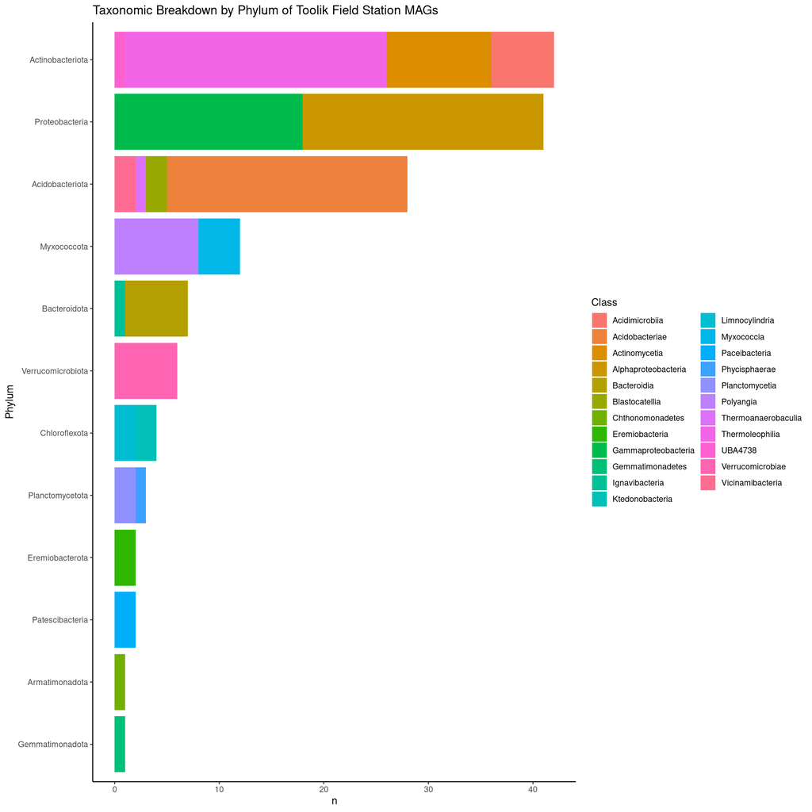

```r
NEON_MAGs_Toolik %>% #Phylum into Order
  ggplot(aes(x=fct_rev(fct_infreq(Phylum)), fill=Class))+geom_bar()+coord_flip()+labs(title="Taxonomic Breakdown by Phylum of Toolik Field Station MAGs", x="Phylum", y="n", fill="Class")+theme_classic()
```

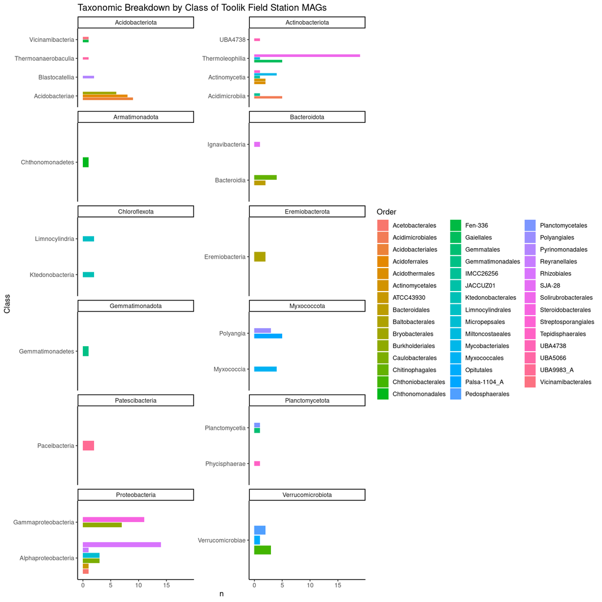

```r
NEON_MAGs_Toolik %>%   #Class into Order
  ggplot(aes(x=Class))+geom_bar(aes(fill=`Order`),position=position_dodge2(width=0.9, preserve="single"))+coord_flip()+facet_wrap(vars(`Phylum`), scales="free_y", ncol=2)+labs(title="Taxonomic Breakdown by Class of Toolik Field Station MAGs", x="Class", y="n", fill="Order")+theme_classic()
```

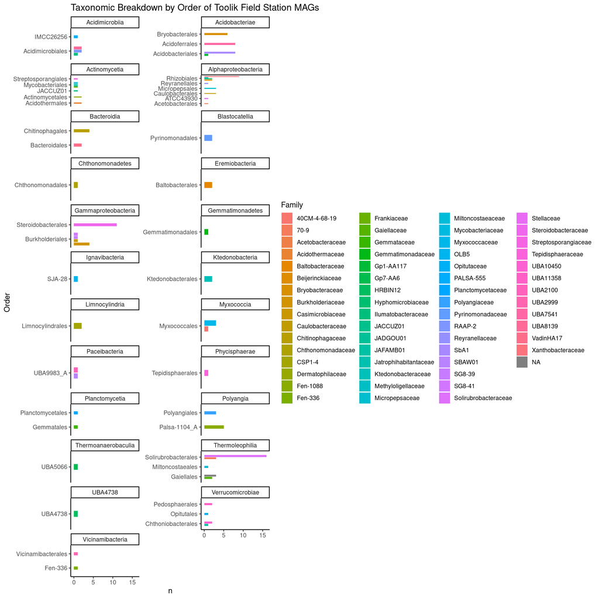

```r
NEON_MAGs_Toolik %>%   #Order into family
  ggplot(aes(x=Order))+geom_bar(aes(fill=`Family`),position=position_dodge2(width=0.9, preserve="single"))+coord_flip()+facet_wrap(vars(`Class`), scales="free_y", ncol=2)+labs(title="Taxonomic Breakdown by Order of Toolik Field Station MAGs", x="Order", y="n", fill="Family")+theme_classic()
```

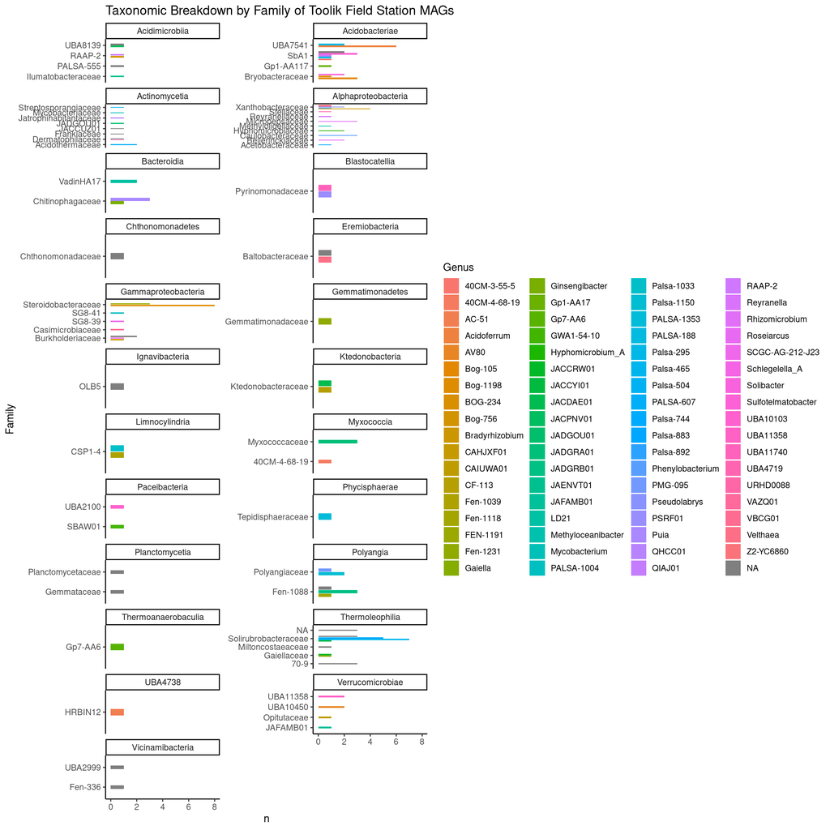

```r
NEON_MAGs_Toolik %>%   #Family into Genus
  ggplot(aes(x=Family))+geom_bar(aes(fill=`Genus`),position=position_dodge2(width=0.9, preserve="single"))+coord_flip()+facet_wrap(vars(`Class`), scales="free_y", ncol=2)+labs(title="Taxonomic Breakdown by Family of Toolik Field Station MAGs", x="Family", y="n", fill="Genus")+theme_classic()
```

## Gammaproteobacteria Site Locations:

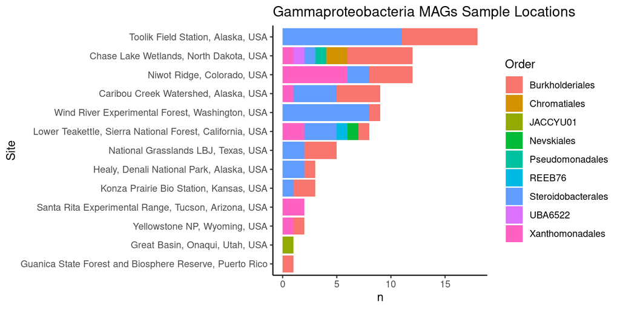

```r
NEON_MAGs_GPROTEO %>% #Site Locations
  filter(!str_detect(`Site`, "NEON combined assembly")) %>%
  ggplot(aes(x=fct_rev(fct_infreq(`Site`)), fill=`Order`))+geom_bar()+coord_flip()+labs(title="Gammaproteobacteria MAGs Sample Locations", x="Site", y="n", fill="Order")+theme_classic()
```

```r
datatable(NEON_MAGs_GPROTEO)
```

|  | Bin ID | Site | Sample Name | Site ID | Subplot | Layer | Date | IMG Genome ID | Bin Quality | Bin Lineage | GTDB-Tk Taxonomy Lineage | Domain | Phylum | Class | Order | Family | Genus | Bin Completeness | Bin Contamination | Total Number of Bases | 5s rRNA | 16s rRNA | 23s rRNA | tRNA Genes | Gene Count | Scaffold Count | Assembly Type |
| --- | --- | --- | --- | --- | --- | --- | --- | --- | --- | --- | --- | --- | --- | --- | --- | --- | --- | --- | --- | --- | --- | --- | --- | --- | --- | --- | --- |
| 1 | 3300060644_52 | Caribou Creek Watershed, Alaska, USA | BONA_009-O-20210707 | BONA | 009 | O | 20210707 | 3300060644 | MQ | Bacteria; Pseudomonadota | Bacteria; Proteobacteria; Gammaproteobacteria; Steroidobacterales; Steroidobacteraceae; Bog-1198 | Bacteria | Proteobacteria | Gammaproteobacteria | Steroidobacterales | Steroidobacteraceae | Bog-1198 | 58.62 | 5.17 | 4153034 | 0 | 0 | 0 | 23 | 4390 | 620 | Individual |
| 2 | 3300060646_17 | Healy, Denali National Park, Alaska, USA | HEAL_048-M-20210622 | HEAL | 048 | M | 20210622 | 3300060646 | MQ | Bacteria; Pseudomonadota | Bacteria; Proteobacteria; Gammaproteobacteria; Steroidobacterales; Steroidobacteraceae; Bog-1198 | Bacteria | Proteobacteria | Gammaproteobacteria | Steroidobacterales | Steroidobacteraceae | Bog-1198 | 73.17 | 6.17 | 3408873 | 0 | 0 | 0 | 28 | 3608 | 501 | Individual |
| 3 | 3300060670_44 | Toolik Field Station, Alaska, USA | TOOL_041-O-20210803 | TOOL | 041 | O | 20210803 | 3300060670 | MQ | Bacteria; Pseudomonadota | Bacteria; Proteobacteria; Gammaproteobacteria; Steroidobacterales; Steroidobacteraceae; Bog-1198 | Bacteria | Proteobacteria | Gammaproteobacteria | Steroidobacterales | Steroidobacteraceae | Bog-1198 | 58.06 | 2.11 | 2920169 | 0 | 0 | 0 | 22 | 3031 | 352 | Individual |
| 4 | 3300060695_43 | Toolik Field Station, Alaska, USA | TOOL_006-O-20210804 | TOOL | 006 | O | 20210804 | 3300060695 | MQ | Bacteria; Pseudomonadota | Bacteria; Proteobacteria; Gammaproteobacteria; Steroidobacterales; Steroidobacteraceae; Bog-1198 | Bacteria | Proteobacteria | Gammaproteobacteria | Steroidobacterales | Steroidobacteraceae | Bog-1198 | 87.37 | 8.33 | 5020742 | 0 | 0 | 0 | 48 | 5150 | 451 | Individual |
| 5 | 3300060695_68 | Toolik Field Station, Alaska, USA | TOOL_006-O-20210804 | TOOL | 006 | O | 20210804 | 3300060695 | MQ | Bacteria; Pseudomonadota | Bacteria; Proteobacteria; Gammaproteobacteria; Steroidobacterales; Steroidobacteraceae; FEN-1191 | Bacteria | Proteobacteria | Gammaproteobacteria | Steroidobacterales | Steroidobacteraceae | FEN-1191 | 58.62 | 3.45 | 3010366 | 0 | 0 | 0 | 13 | 3157 | 454 | Individual |
| 6 | 3300060695_90 | Toolik Field Station, Alaska, USA | TOOL_006-O-20210804 | TOOL | 006 | O | 20210804 | 3300060695 | MQ | Bacteria; Pseudomonadota | Bacteria; Proteobacteria; Gammaproteobacteria; Steroidobacterales; Steroidobacteraceae; Bog-1198 | Bacteria | Proteobacteria | Gammaproteobacteria | Steroidobacterales | Steroidobacteraceae | Bog-1198 | 88.73 | 5.84 | 4377785 | 0 | 1 | 0 | 36 | 4366 | 322 | Individual |
| 7 | 3300060780_7 | Wind River Experimental Forest, Washington, USA | WREF_003-M-20210622 | WREF | 003 | M | 20210622 | 3300060780 | MQ | Bacteria; Pseudomonadota | Bacteria; Proteobacteria; Gammaproteobacteria; Steroidobacterales; Steroidobacteraceae; Bog-1198 | Bacteria | Proteobacteria | Gammaproteobacteria | Steroidobacterales | Steroidobacteraceae | Bog-1198 | 86.29 | 3.44 | 4304465 | 1 | 0 | 0 | 29 | 3895 | 115 | Individual |
| 8 | 3300060885_28 | Chase Lake Wetlands, North Dakota, USA | WOOD_004-M-20210714 | WOOD | 004 | M | 20210714 | 3300060885 | MQ | Bacteria; Pseudomonadota | Bacteria; Proteobacteria; Gammaproteobacteria; UBA6522; UBA6522 | Bacteria | Proteobacteria | Gammaproteobacteria | UBA6522 | UBA6522 |  | 61.29 | 4.13 | 3072016 | 0 | 1 | 0 | 23 | 3186 | 475 | Individual |
| 9 | 3300060889_3 | Wind River Experimental Forest, Washington, USA | WREF_004-O-20210622 | WREF | 004 | O | 20210622 | 3300060889 | MQ | Bacteria; Pseudomonadota | Bacteria; Proteobacteria; Gammaproteobacteria; Steroidobacterales; Steroidobacteraceae; Bog-1198 | Bacteria | Proteobacteria | Gammaproteobacteria | Steroidobacterales | Steroidobacteraceae | Bog-1198 | 78.72 | 9.33 | 4610152 | 1 | 0 | 1 | 74 | 4996 | 538 | Individual |
| 10 | 3300060913_57 | Toolik Field Station, Alaska, USA | TOOL_004-O-20210805 | TOOL | 004 | O | 20210805 | 3300060913 | MQ | Bacteria; Pseudomonadota | Bacteria; Proteobacteria; Gammaproteobacteria; Steroidobacterales; Steroidobacteraceae; Bog-1198 | Bacteria | Proteobacteria | Gammaproteobacteria | Steroidobacterales | Steroidobacteraceae | Bog-1198 | 65.15 | 9.03 | 3178283 | 0 | 1 | 0 | 20 | 3311 | 487 | Individual |

[output cut: 114 more lines]

# Exercise 4

```r
NEON_Meta <- read_tsv("~/Bio 676/Lab10/data/NEON_Meta.tsv")
NEON_META_Toolik <- NEON_Meta %>%
  filter(str_detect(`Genome Name / Sample Name`,'re-annotation')) %>%
  filter(str_detect(`Genome Name / Sample Name`,'Toolik Field Station'))

datatable(NEON_META_Toolik)
```

|  | taxon_oid | Domain | Sequencing Status | Study Name | Genome Name / Sample Name | Sequencing Center | IMG Genome ID | GOLD Study ID | Ecosystem | Ecosystem Category | Ecosystem Subtype | Ecosystem Type | Specific Ecosystem | Latitude | Longitude | Genome Size * assembled | Gene Count * assembled |
| --- | --- | --- | --- | --- | --- | --- | --- | --- | --- | --- | --- | --- | --- | --- | --- | --- | --- |
| 1 | 3300069247 | *Microbiome | Permanent Draft | Terrestrial soil microbial communities from various NEON sites located in USA and Puerto Rico | Terrestrial soil microbial communities from Toolik Field Station, Alaska, USA - TOOL_002-O-20210804-comp-1 re-annotation | DOE Joint Genome Institute (JGI) | 3300069247 | Gs0161344 | Environmental | Terrestrial | Tundra | Soil | Unclassified | 68.627943 | -149.347229 | 2203447209 | 4867161 |
| 2 | 3300069278 | *Microbiome | Permanent Draft | Terrestrial soil microbial communities from various NEON sites located in USA and Puerto Rico | Terrestrial soil microbial communities from Toolik Field Station, Alaska, USA - TOOL_042-O-20210803-comp-1 re-annotation | DOE Joint Genome Institute (JGI) | 3300069278 | Gs0161344 | Environmental | Terrestrial | Tundra | Soil | Unclassified | 68.664072 | -149.381292 | 2672095979 | 6305045 |
| 3 | 3300069299 | *Microbiome | Permanent Draft | Terrestrial soil microbial communities from various NEON sites located in USA and Puerto Rico | Terrestrial soil microbial communities from Toolik Field Station, Alaska, USA - TOOL_003-O-20210805-comp-1 re-annotation | DOE Joint Genome Institute (JGI) | 3300069299 | Gs0161344 | Environmental | Terrestrial | Tundra | Soil | Unclassified | 68.640255 | -149.642461 | 1673591034 | 4090741 |
| 4 | 3300069281 | *Microbiome | Permanent Draft | Terrestrial soil microbial communities from various NEON sites located in USA and Puerto Rico | Terrestrial soil microbial communities from Toolik Field Station, Alaska, USA - TOOL_006-O-20210804-comp-1 re-annotation | DOE Joint Genome Institute (JGI) | 3300069281 | Gs0161344 | Environmental | Terrestrial | Tundra | Soil | Unclassified | 68.622127 | -149.280182 | 4057418107 | 9034481 |
| 5 | 3300069276 | *Microbiome | Permanent Draft | Terrestrial soil microbial communities from various NEON sites located in USA and Puerto Rico | Terrestrial soil microbial communities from Toolik Field Station, Alaska, USA - TOOL_005-O-20210806-comp-1 re-annotation | DOE Joint Genome Institute (JGI) | 3300069276 | Gs0161344 | Environmental | Terrestrial | Tundra | Soil | Unclassified | 68.560148 | -149.528532 | 2791483050 | 6003735 |
| 6 | 3300069231 | *Microbiome | Permanent Draft | Terrestrial soil microbial communities from various NEON sites located in USA and Puerto Rico | Terrestrial soil microbial communities from Toolik Field Station, Alaska, USA - TOOL_004-O-20210805-comp-1 re-annotation | DOE Joint Genome Institute (JGI) | 3300069231 | Gs0161344 | Environmental | Terrestrial | Tundra | Soil | Unclassified | 68.616768 | -149.629355 | 3712371654 | 7327615 |
| 7 | 3300069263 | *Microbiome | Permanent Draft | Terrestrial soil microbial communities from various NEON sites located in USA and Puerto Rico | Terrestrial soil microbial communities from Toolik Field Station, Alaska, USA - TOOL_041-O-20210803-comp-1 re-annotation | DOE Joint Genome Institute (JGI) | 3300069263 | Gs0161344 | Environmental | Terrestrial | Tundra | Soil | Unclassified | 68.666666 | -149.369752 | 3221413903 | 6875234 |
| 8 | 3300069228 | *Microbiome | Permanent Draft | Terrestrial soil microbial communities from various NEON sites located in USA and Puerto Rico | Terrestrial soil microbial communities from Toolik Field Station, Alaska, USA - TOOL_043-O-20210803-comp-1 re-annotation | DOE Joint Genome Institute (JGI) | 3300069228 | Gs0161344 | Environmental | Terrestrial | Tundra | Soil | Unclassified | 68.665514 | -149.375519 | 3471645120 | 7803917 |

# References

Gao, Beile, Ritu Mohan, and Radhey S. Gupta. 2009. “Phylogenomics and Protein Signatures Elucidating the Evolutionary Relationships Among the Gammaproteobacteria.” *International Journal of Systematic and Evolutionary Microbiology* 59 (2): 234–47. https://doi.org/10.1099/ijs.0.002741-0.

Liao, Hu, Xiaolan Lin, Yuqian Li, Mingming Qu, and Yun Tian. 2020. “Reclassification of the Taxonomic Framework of Orders Cellvibrionales, Oceanospirillales, Pseudomonadales, and Alteromonadales in Class Gammaproteobacteria Through Phylogenomic Tree Analysis.” *mSystems* 5 (5): 10.1128/msystems.00543–20. https://doi.org/10.1128/msystems.00543-20.

NEON, Collection. 2023. “Collection - Getting to Know the NEON Domains.” *ArcGIS StoryMaps*. https://storymaps.arcgis.com/collections/5765fc95c3c24297a5b9dc2c99e69e5c.

University of Alaska Fairbanks, Collection. n.d. “Photo Gallery Toolik Field Station.” Accessed April 2, 2024. https://www.uaf.edu/toolik/about/toolik-gallery.php.

Williams, Kelly P., Joseph J. Gillespie, Bruno W. S. Sobral, Eric K. Nordberg, Eric E. Snyder, Joshua M. Shallom, and Allan W. Dickerman. 2010. “Phylogeny of Gammaproteobacteria.” *Journal of Bacteriology* 192 (9): 2305–14. https://doi.org/10.1128/JB.01480-09.

Williams, Kelly P., and Donovan P. Kelly. 2013. “Proposal for a New Class Within the Phylum Proteobacteria, Acidithiobacillia Classis Nov., With the Type Order Acidithiobacillales, and Emended Description of the Class Gammaproteobacteria.” *International Journal of Systematic and Evolutionary Microbiology* 63 (Pt_8): 2901–6. https://doi.org/10.1099/ijs.0.049270-0.